# Equity-Informed Access Improvement Simulator for British Columbia

A reproducible, synthetic-data capability demonstrator (version 2.0.0)

Author

Christopher Bwanika

Published

1 October 2026

**WarningSynthetic-data capability demonstrator**

All data, inputs and results in this report are **simulated** to illustrate methods. This is not an official analysis, recommendation, endorsement or evaluation by any government, health authority, agency or community, and no result describes a real population or programme.

# 1 Summary

**Decision question (hypothetical).** For adults referred into a diagnostic or specialist pathway, should a health system offer patient navigation to everyone, only to patients facing the highest structural barriers, or to no one (usual care)?

**What the prototype shows (illustrative results only).**

- In the base case, targeted navigation costs CAD 16,986 per QALY gained compared with usual care, and moving from targeted to universal navigation costs CAD 57,894 per QALY. At CAD 50,000 per QALY the strategy with the highest net monetary benefit is **Targeted navigation**.
- Navigation is far better value where barriers are highest: CAD 16,986 per QALY in the higher-barrier group against CAD 107,931 in the lower-barrier group.
- In the probabilistic analysis, the probability that targeted navigation is optimal at CAD 50,000 per QALY is 68% (universal: 31%).
- Distributional analysis: targeted navigation both adds health and narrows the gap between groups in 99.2% of PSA draws. At CAD 100,000 per QALY universal navigation yields more total health, and targeted navigation is preferred only with Atkinson inequality aversion of at least 17 - a genuine equity-efficiency trade-off.

These are **assumption-dependent simulated outputs**, produced to demonstrate an auditable workflow. They are not evidence about any real programme.

# 2 Decision problem

| Element | Specification |
| --- | --- |
| Population | Synthetic cohort of adults aged 55 referred into a diagnostic/specialist pathway, in three structural-barrier groups |
| Strategies | Usual care; targeted navigation (higher-barrier group only); universal navigation (all groups) |
| Perspective | Publicly funded health system (costs); household non-medical costs reported separately (ECEA-lite) |
| Time horizon | Lifetime (to age 100), quarterly cycles |
| Discounting | 1.5% per year for costs and QALYs (CDA-AMC reference case); 0% and 3% in scenarios |
| Outcomes | Costs, QALYs, life-years, acute events, time unresolved; NMB; distribution of health; household burden |
| Currency | Canadian dollars, illustrative values (no price-year adjustment applies to synthetic inputs) |
| Threshold | CAD 50,000 per QALY for illustration; results shown from 0 to 150,000 |

# 3 Model

A cohort state-transition (Markov) model with four states and quarterly cycles. Transitions are built as sequential conditional probabilities, so every row of every transition matrix sums to one by construction. Navigation multiplies the hazard of completing the pathway for navigated patients while support lasts (4 quarters); uptake is lower in higher-barrier groups. Offered groups are modelled as an exact uptake-weighted mix of a navigated and a non-navigated sub-cohort.

```
flowchart LR
  U[Unresolved] -->|pathway completed| M[Managed]
  M -->|disengages| U
  U -->|acute event| A[Acute event<br/>one quarter]
  M -->|acute event| A
  A -->|survives, enters care| M
  A -->|survives, not in care| U
  U --> D[Dead]
  M --> D
  A --> D
```

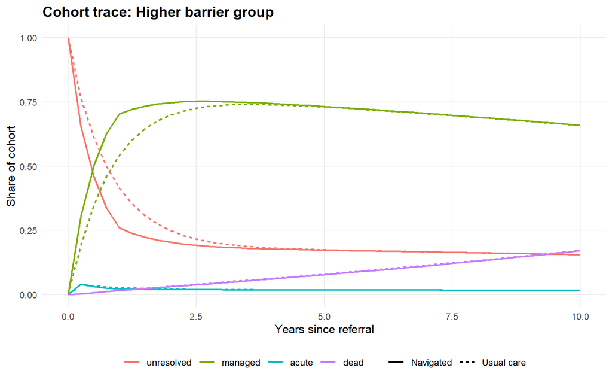

Figure 1: Cohort trace for the higher-barrier group, first 10 years.

## 3.1 Inputs

Every input, its distribution and its rationale is held in `data/parameters.csv`. `value` is the distribution mean and `se` its standard error.

| parameter | group | value | se | distribution | unit | source_type |
| --- | --- | --- | --- | --- | --- | --- |
| start_age | all | 5.50e+01 |  | fixed | years | structural_choice |
| cycle_length | all | 2.50e-01 |  | fixed | years | structural_choice |
| horizon_years | all | 4.50e+01 |  | fixed | years | structural_choice |
| discount_rate | all | 1.50e-02 |  | fixed | per year | guideline |
| k_threshold | all | 5.00e+04 |  | fixed | CAD per QALY | illustrative_threshold |
| n_cohort | all | 1.00e+04 |  | fixed | patients | synthetic_assumption |
| n_population | all | 1.00e+06 |  | fixed | people | synthetic_assumption |
| gompertz_a | all | 0.00e+00 |  | fixed | per year | synthetic_assumption |
| gompertz_b | all | 9.50e-02 |  | fixed | per year of age | synthetic_assumption |
| hr_acute_managed | all | 3.50e-01 | 0.070 | lognormal | hazard ratio | synthetic_assumption |
| p_case_fatality | all | 8.00e-02 | 0.015 | beta | probability per event | synthetic_assumption |
| p_post_acute_managed | all | 5.50e-01 | 0.080 | beta | probability | synthetic_assumption |
| u_managed | all | 8.00e-01 | 0.020 | beta | utility | synthetic_assumption |
| dec_unresolved | all | 7.00e-02 | 0.020 | gamma | utility decrement | synthetic_assumption |
| dec_acute | all | 3.00e-01 | 0.050 | gamma | utility decrement | synthetic_assumption |
| c_unresolved | all | 3.50e+02 | 70.000 | gamma | CAD per quarter | synthetic_assumption |
| c_managed | all | 5.20e+02 | 104.000 | gamma | CAD per quarter | synthetic_assumption |
| c_acute | all | 9.50e+03 | 1,900.000 | gamma | CAD per acute event | synthetic_assumption |
| c_navigation | all | 7.50e+02 | 150.000 | gamma | CAD per navigated patient | synthetic_assumption |
| nav_cycles | all | 4.00e+00 |  | fixed | cycles | structural_choice |
| p_complete | lower_barrier | 4.50e-01 | 0.040 | beta | probability per quarter | synthetic_assumption |
| p_complete | moderate_barrier | 3.30e-01 | 0.040 | beta | probability per quarter | synthetic_assumption |
| p_complete | higher_barrier | 2.00e-01 | 0.030 | beta | probability per quarter | synthetic_assumption |
| p_acute_unresolved | lower_barrier | 2.50e-02 | 0.005 | beta | probability per quarter | synthetic_assumption |
| p_acute_unresolved | moderate_barrier | 3.00e-02 | 0.006 | beta | probability per quarter | synthetic_assumption |
| p_acute_unresolved | higher_barrier | 4.00e-02 | 0.008 | beta | probability per quarter | synthetic_assumption |
| p_disengage | lower_barrier | 1.50e-02 | 0.004 | beta | probability per quarter | synthetic_assumption |
| p_disengage | moderate_barrier | 2.50e-02 | 0.006 | beta | probability per quarter | synthetic_assumption |
| p_disengage | higher_barrier | 4.50e-02 | 0.010 | beta | probability per quarter | synthetic_assumption |
| hr_bg_mortality | lower_barrier | 1.00e+00 |  | fixed | hazard ratio | synthetic_assumption |
| hr_bg_mortality | moderate_barrier | 1.20e+00 |  | fixed | hazard ratio | synthetic_assumption |
| hr_bg_mortality | higher_barrier | 1.50e+00 |  | fixed | hazard ratio | synthetic_assumption |
| uptake | lower_barrier | 8.00e-01 | 0.050 | beta | proportion | synthetic_assumption |
| uptake | moderate_barrier | 7.50e-01 | 0.050 | beta | proportion | synthetic_assumption |
| uptake | higher_barrier | 6.50e-01 | 0.070 | beta | proportion | synthetic_assumption |
| hr_navigation | lower_barrier | 1.15e+00 | 0.080 | lognormal | hazard ratio | synthetic_assumption |
| hr_navigation | moderate_barrier | 1.35e+00 | 0.120 | lognormal | hazard ratio | synthetic_assumption |
| hr_navigation | higher_barrier | 1.70e+00 | 0.200 | lognormal | hazard ratio | synthetic_assumption |
| hh_income_sdlog | all | 6.00e-01 |  | fixed | log-scale SD | synthetic_assumption |
| burden_threshold | all | 5.00e-02 |  | fixed | share of annual income | synthetic_assumption |
| hh_cost_unresolved | lower_barrier | 1.20e+02 |  | fixed | CAD per quarter | synthetic_assumption |
| hh_cost_unresolved | moderate_barrier | 1.80e+02 |  | fixed | CAD per quarter | synthetic_assumption |
| hh_cost_unresolved | higher_barrier | 2.60e+02 |  | fixed | CAD per quarter | synthetic_assumption |
| hh_cost_managed | lower_barrier | 5.00e+01 |  | fixed | CAD per quarter | synthetic_assumption |
| hh_cost_managed | moderate_barrier | 7.00e+01 |  | fixed | CAD per quarter | synthetic_assumption |
| hh_cost_managed | higher_barrier | 1.00e+02 |  | fixed | CAD per quarter | synthetic_assumption |
| hh_cost_acute | lower_barrier | 9.00e+02 |  | fixed | CAD per acute event | synthetic_assumption |
| hh_cost_acute | moderate_barrier | 1.10e+03 |  | fixed | CAD per acute event | synthetic_assumption |
| hh_cost_acute | higher_barrier | 1.40e+03 |  | fixed | CAD per acute event | synthetic_assumption |
| hh_income_median | lower_barrier | 9.50e+04 |  | fixed | CAD per year | synthetic_assumption |
| hh_income_median | moderate_barrier | 6.50e+04 |  | fixed | CAD per year | synthetic_assumption |
| hh_income_median | higher_barrier | 4.00e+04 |  | fixed | CAD per year | synthetic_assumption |

# 4 Cost-effectiveness results

## 4.1 Base case (deterministic)

| Strategy | Cost (CAD) | QALYs | Life-years | Acute events | NMB (CAD) |
| --- | --- | --- | --- | --- | --- |
| Usual care | 47,988.98 | 15.2285 | 19.3353 | 1.2626 | 713,435.4 |
| Targeted navigation | 48,141.59 | 15.2375 | 19.3420 | 1.2582 | 713,732.0 |
| Universal navigation | 48,561.66 | 15.2447 | 19.3469 | 1.2552 | 713,674.8 |

| Strategy | Status | Incremental cost | Incremental QALYs | ICER (CAD/QALY) |
| --- | --- | --- | --- | --- |
| Usual care | on frontier |  |  |  |
| Targeted navigation | on frontier | 152.6147 | 0.0090 | 16,985.55 |
| Universal navigation | on frontier | 420.0698 | 0.0073 | 57,893.64 |

Per-patient results by group (offered groups include uptake):

| strategy | group | cost | qaly | acute_events | time_unresolved | managed_1y |
| --- | --- | --- | --- | --- | --- | --- |
| Usual care | Lower barrier | 49,348.60 | 16.3773 | 0.9882 | 1.3831 | 0.8651 |
| Usual care | Moderate barrier | 47,760.59 | 15.3194 | 1.1859 | 2.3798 | 0.7472 |
| Usual care | Higher barrier | 46,669.20 | 13.7821 | 1.6721 | 4.6402 | 0.5429 |
| Targeted navigation | Lower barrier | 49,348.60 | 16.3773 | 0.9882 | 1.3831 | 0.8651 |
| Targeted navigation | Moderate barrier | 47,760.59 | 15.3194 | 1.1859 | 2.3798 | 0.7472 |
| Targeted navigation | Higher barrier | 47,177.91 | 13.8121 | 1.6574 | 4.4805 | 0.6473 |
| Universal navigation | Lower barrier | 49,961.38 | 16.3830 | 0.9860 | 1.3466 | 0.8863 |
| Universal navigation | Moderate barrier | 48,348.02 | 15.3345 | 1.1795 | 2.2892 | 0.8064 |
| Universal navigation | Higher barrier | 47,177.91 | 13.8121 | 1.6574 | 4.4805 | 0.6473 |

## 4.2 One-way and scenario analyses

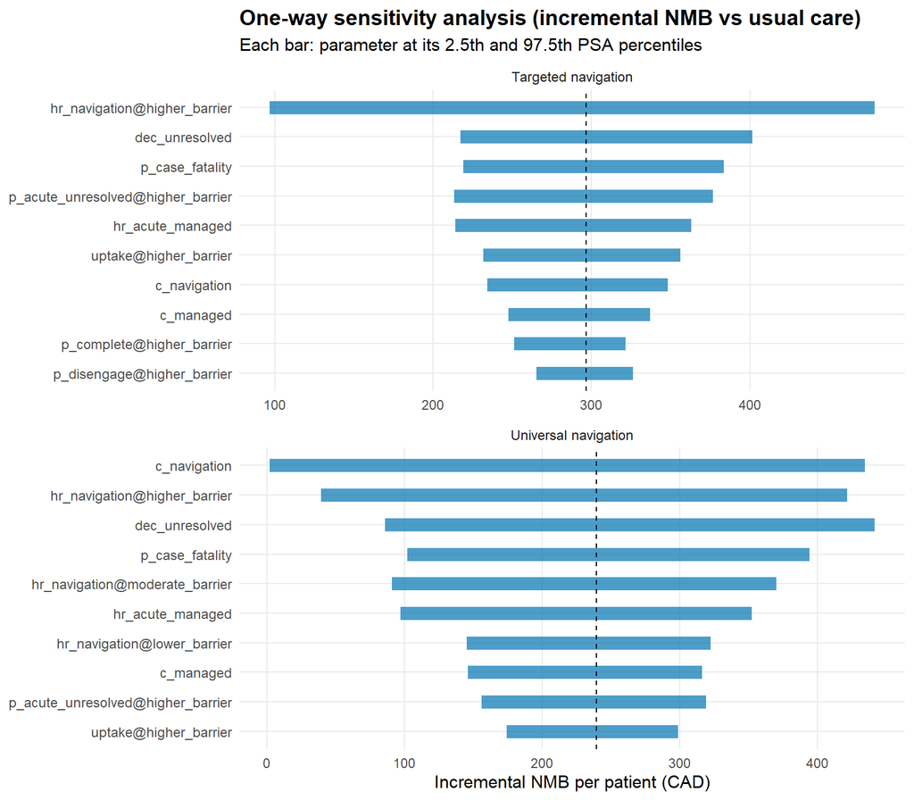

Figure 2: One-way sensitivity analysis: each input at its 2.5th and 97.5th PSA percentile.

| scenario | strategy | inc_cost | inc_qaly | inc_nmb | icer_vs_usual_care | optimal_strategy |
| --- | --- | --- | --- | --- | --- | --- |
| Base case | Targeted navigation | 152.6147 | 0.0090 | 296.6340 | 16,985.55 | Targeted navigation |
| Base case | Universal navigation | 572.6845 | 0.0162 | 239.3586 | 35,261.95 | Targeted navigation |
| Discount rate 0% | Targeted navigation | 156.2112 | 0.0102 | 355.4356 | 15,265.53 | Targeted navigation |
| Discount rate 0% | Universal navigation | 579.1206 | 0.0185 | 345.1590 | 31,328.22 | Targeted navigation |
| Discount rate 3% | Targeted navigation | 150.0009 | 0.0080 | 251.8533 | 18,663.60 | Targeted navigation |
| Discount rate 3% | Universal navigation | 568.0142 | 0.0146 | 159.6483 | 39,030.06 | Targeted navigation |
| 10-year horizon | Targeted navigation | 142.6810 | 0.0060 | 158.8516 | 23,659.30 | Targeted navigation |
| 10-year horizon | Universal navigation | 555.6205 | 0.0110 | -7.0016 | 50,638.11 | Targeted navigation |
| No within-cycle correction | Targeted navigation | 152.6149 | 0.0090 | 296.6368 | 16,985.46 | Targeted navigation |
| No within-cycle correction | Universal navigation | 572.6852 | 0.0162 | 239.3696 | 35,261.49 | Targeted navigation |
| Navigation lasts 2 years | Targeted navigation | 154.5021 | 0.0118 | 437.6821 | 13,045.10 | Universal navigation |
| Navigation lasts 2 years | Universal navigation | 576.7719 | 0.0204 | 441.1111 | 28,331.93 | Universal navigation |
| Equal uptake (0.80) in all groups | Targeted navigation | 187.8335 | 0.0111 | 365.0880 | 16,985.55 | Targeted navigation |
| Equal uptake (0.80) in all groups | Universal navigation | 621.6099 | 0.0187 | 311.6686 | 33,302.49 | Targeted navigation |
| Equal navigation effect (HR 1.35) in all groups | Targeted navigation | 149.8134 | 0.0050 | 102.0127 | 29,745.41 | Universal navigation |
| Equal navigation effect (HR 1.35) in all groups | Universal navigation | 574.5262 | 0.0144 | 143.2633 | 40,020.52 | Universal navigation |
| Navigation cost +50% | Targeted navigation | 225.7397 | 0.0090 | 223.5090 | 25,124.14 | Targeted navigation |
| Navigation cost +50% | Universal navigation | 849.2470 | 0.0162 | -37.2039 | 52,290.76 | Targeted navigation |
| No mortality gradient between groups | Targeted navigation | 154.7896 | 0.0097 | 328.4200 | 16,016.81 | Targeted navigation |
| No mortality gradient between groups | Universal navigation | 575.3324 | 0.0171 | 278.4962 | 33,691.33 | Targeted navigation |
| Threshold CAD 30,000 per QALY | Targeted navigation | 152.6147 | 0.0090 | 116.9345 | 16,985.55 | Targeted navigation |
| Threshold CAD 30,000 per QALY | Universal navigation | 572.6845 | 0.0162 | -85.4586 | 35,261.95 | Targeted navigation |
| Threshold CAD 100,000 per QALY | Targeted navigation | 152.6147 | 0.0090 | 745.8826 | 16,985.55 | Universal navigation |
| Threshold CAD 100,000 per QALY | Universal navigation | 572.6845 | 0.0162 | 1,051.4018 | 35,261.95 | Universal navigation |

## 4.3 Probabilistic sensitivity analysis

2,000 iterations; one parameter draw is shared by all strategies and groups within an iteration.

| Strategy | Mean incremental cost | 2.5% | 97.5% | Mean incremental QALYs | 2.5% | 97.5% |
| --- | --- | --- | --- | --- | --- | --- |
| Usual care | 0.0000 | 0.0000 | 0.0000 | 0.0000 | 0.0000 | 0.0000 |
| Targeted navigation | 151.7001 | 74.8043 | 246.1751 | 0.0087 | 0.0041 | 0.0151 |
| Universal navigation | 571.3837 | 347.6201 | 845.5246 | 0.0158 | 0.0090 | 0.0243 |

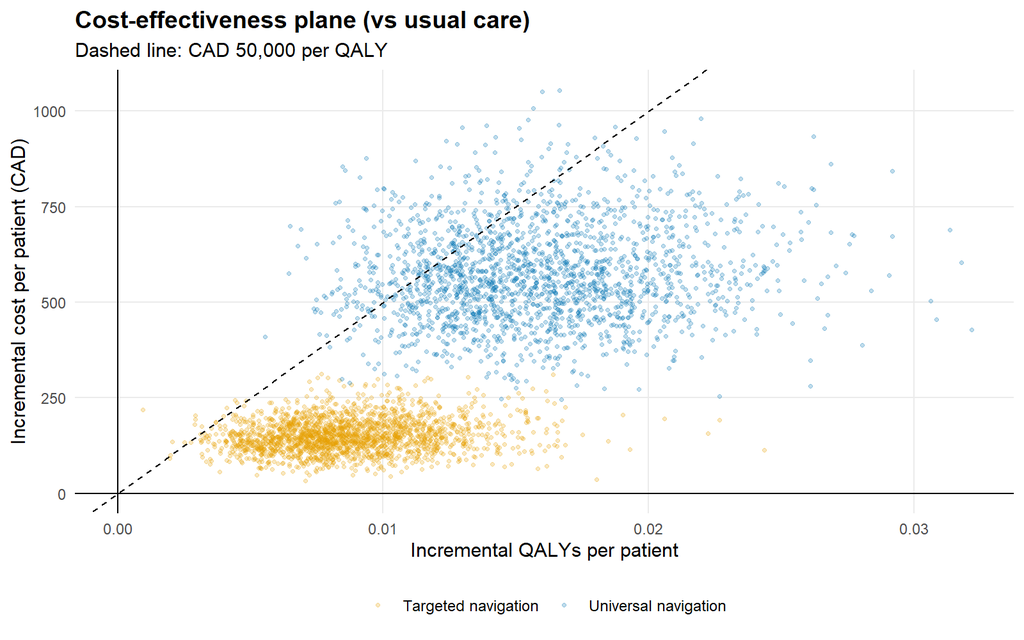

Figure 3: Cost-effectiveness plane.

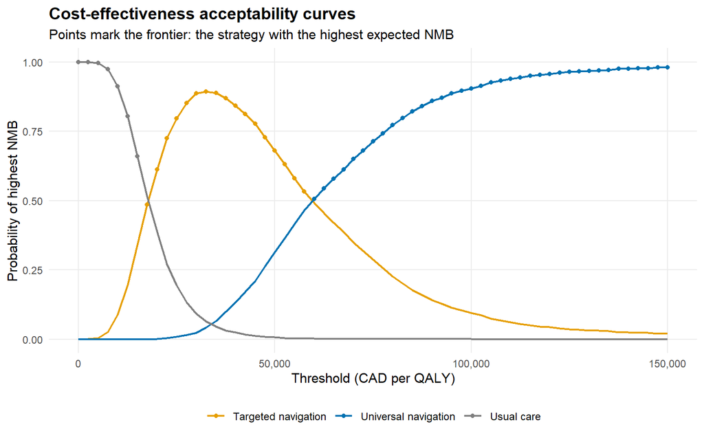

Figure 4: Cost-effectiveness acceptability curves and frontier.

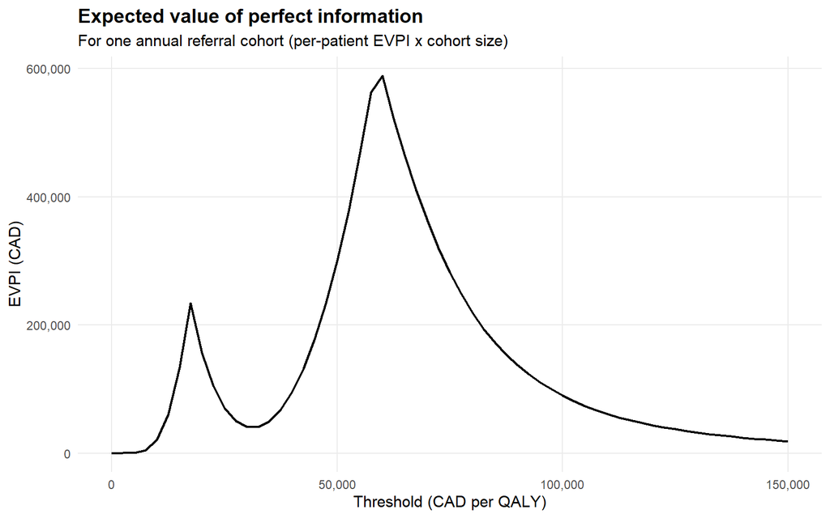

Figure 5: Expected value of perfect information for one annual cohort.

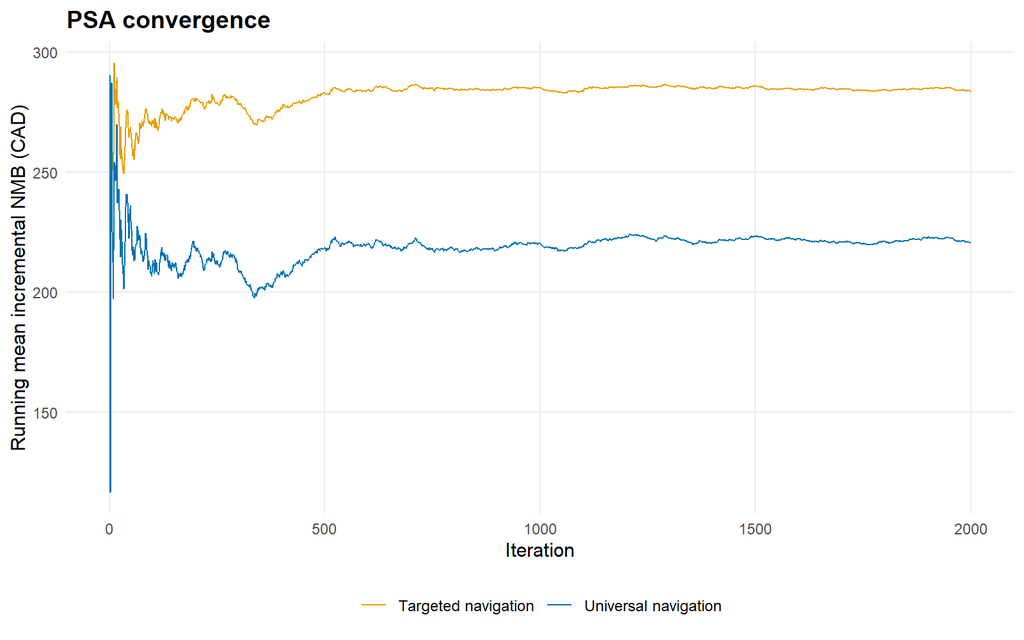

Figure 6: Convergence of the PSA mean incremental NMB.

# 5 Distributional cost-effectiveness analysis

Health gains by group are combined with health opportunity costs (incremental cost divided by the threshold), shared across groups by an explicit rule. The base case shares them in proportion to population; two other rules are reported as scenarios, informed by English evidence that displaced health falls more heavily on deprived groups.

| Strategy | Opportunity-cost rule | Net health benefit (QALYs) | Gap reduction (days/person) | EW-NHB e=0 | EW-NHB e=5 | EW-NHB e=10 | EW-NHB Kolm 0.15 |
| --- | --- | --- | --- | --- | --- | --- | --- |
| Targeted navigation | oc_proportional | 59.327 | 0.164 | 59.327 | 119.103 | 191.667 | 184.427 |
| Targeted navigation | oc_higher_concentrated | 59.327 | 0.156 | 59.327 | 116.232 | 185.537 | 178.527 |
| Targeted navigation | oc_lower_concentrated | 59.327 | 0.169 | 59.327 | 121.020 | 195.492 | 188.160 |
| Universal navigation | oc_proportional | 47.872 | 0.150 | 47.872 | 103.627 | 166.200 | 160.792 |
| Universal navigation | oc_higher_concentrated | 47.872 | 0.120 | 47.872 | 92.854 | 143.198 | 138.654 |
| Universal navigation | oc_lower_concentrated | 47.872 | 0.168 | 47.872 | 110.820 | 180.554 | 174.800 |

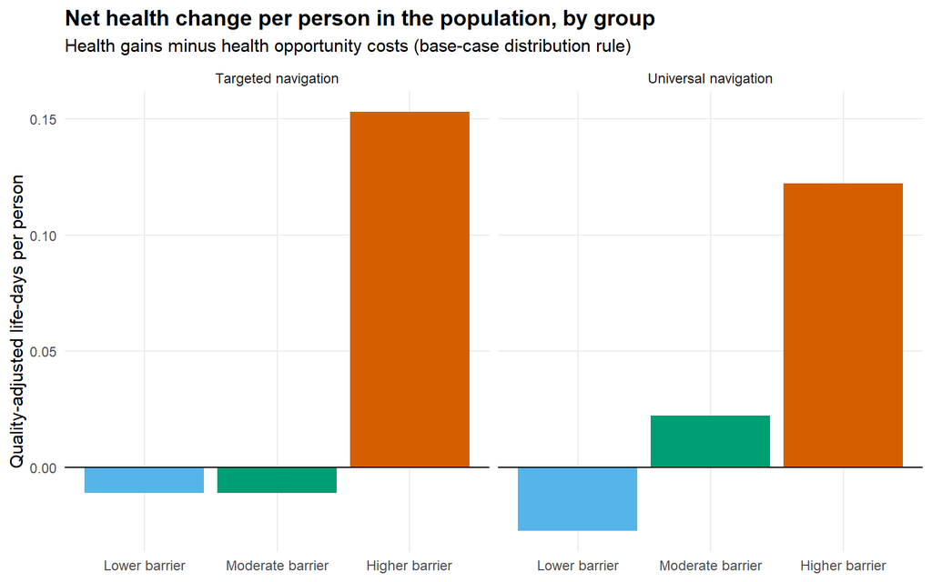

Figure 7: Net health change per person by group.

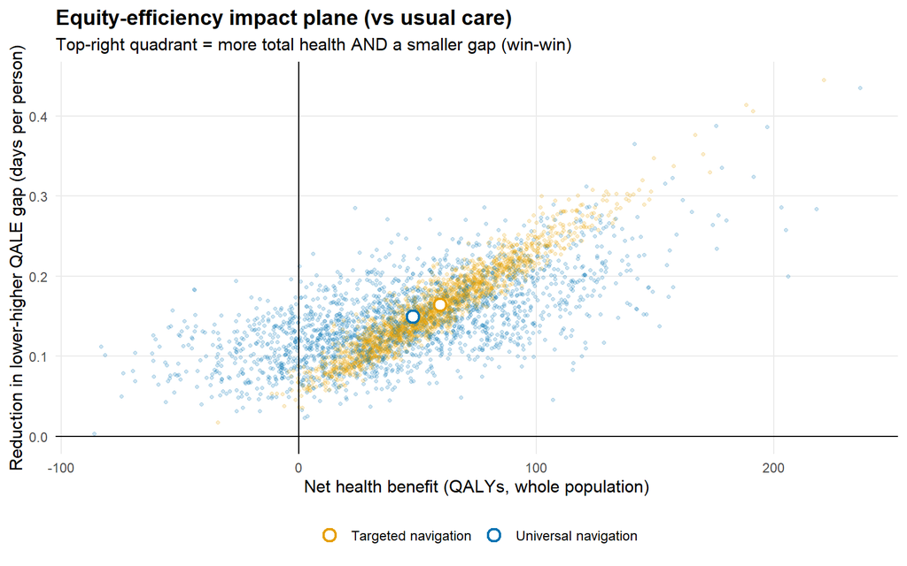

Figure 8: Equity-efficiency impact plane (PSA draws and base case).

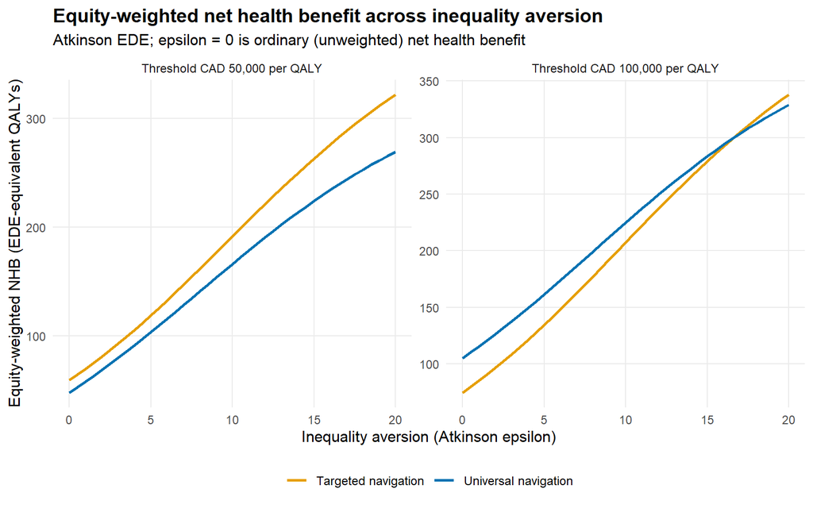

Figure 9: Equity-weighted net health benefit across inequality aversion.

| Strategy | P(more health) | P(smaller gap) | P(both) |
| --- | --- | --- | --- |
| Targeted navigation | 0.992 | 1 | 0.992 |
| Universal navigation | 0.836 | 1 | 0.836 |

Inequality aversion is a value judgement, so results are shown across a range. For reference, a survey of the English public found median values of about 11 (Atkinson) and 0.15 (Kolm).

# 6 ECEA-lite: household non-medical burden

First-year household non-medical costs (travel, time off work, missed appointments, lost income during acute events) are simulated for individual patients through the same transition matrices as the cohort model. This is a financial-burden extension, not a full ECEA and not a measure of catastrophic health expenditure.

| strategy | group | mean_hh_cost | share_above_0.025 | share_above_0.05 | share_above_0.1 | high_burden_averted_per_1000 |
| --- | --- | --- | --- | --- | --- | --- |
| Usual care | Lower barrier | 336.6405 | 0.0083 | 0.0008 | 0.0000 | 0.00 |
| Targeted navigation | Lower barrier | 336.6405 | 0.0083 | 0.0008 | 0.0000 | 0.00 |
| Universal navigation | Lower barrier | 327.2325 | 0.0081 | 0.0008 | 0.0000 | 0.00 |
| Usual care | Moderate barrier | 550.7465 | 0.0644 | 0.0102 | 0.0008 | 0.00 |
| Targeted navigation | Moderate barrier | 550.7465 | 0.0644 | 0.0102 | 0.0008 | 0.00 |
| Universal navigation | Moderate barrier | 517.5475 | 0.0574 | 0.0092 | 0.0006 | 1.00 |
| Usual care | Higher barrier | 934.1590 | 0.4019 | 0.1288 | 0.0226 | 0.00 |
| Targeted navigation | Higher barrier | 866.6530 | 0.3566 | 0.1110 | 0.0199 | 17.75 |
| Universal navigation | Higher barrier | 866.6530 | 0.3566 | 0.1110 | 0.0199 | 17.75 |

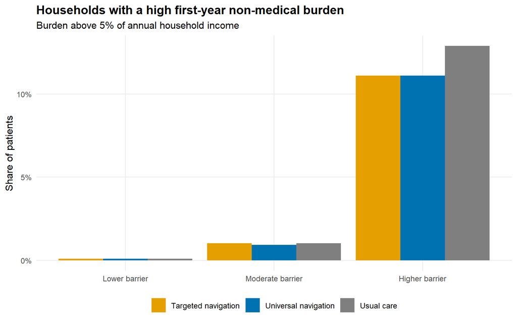

Figure 10: Share of households above the high-burden threshold.

Cross-validation of the microsimulation against the cohort model:

| group | cohort_expected_not_offered | micro_mean_not_offered | micro_se_not_offered | cohort_expected_offered | micro_mean_offered | micro_se_offered |
| --- | --- | --- | --- | --- | --- | --- |
| lower_barrier | 335.33 | 336.64 | 1.67 | 325.29 | 327.23 | 1.65 |
| moderate_barrier | 547.21 | 550.75 | 2.37 | 513.81 | 517.55 | 2.33 |
| higher_barrier | 930.90 | 934.16 | 3.45 | 861.25 | 866.65 | 3.47 |

# 7 Causal-evidence demonstrations

## 7.1 Interrupted time series

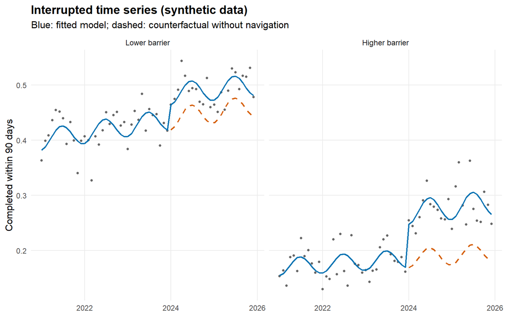

Figure 11: Synthetic ITS: observed, fitted and counterfactual series.

| group | analysis | term | estimate | ci_lo | ci_hi | planted |
| --- | --- | --- | --- | --- | --- | --- |
| Lower barrier | main | post | 0.1839 | 0.0312 | 0.3366 | 0.1482 |
| Lower barrier | main | time_after | -0.0014 | -0.0113 | 0.0085 | 0.0000 |
| Higher barrier | main | post | 0.4818 | 0.3104 | 0.6532 | 0.4125 |
| Higher barrier | main | time_after | 0.0009 | -0.0097 | 0.0115 | 0.0000 |
| Lower barrier | placebo (pre-period only) | post | 0.2266 | 0.0885 | 0.3646 | 0.0000 |
| Lower barrier | placebo (pre-period only) | time_after | 0.0071 | -0.0060 | 0.0201 | 0.0000 |
| Higher barrier | placebo (pre-period only) | post | -0.1105 | -0.2745 | 0.0534 | 0.0000 |
| Higher barrier | placebo (pre-period only) | time_after | 0.0081 | -0.0072 | 0.0233 | 0.0000 |
| Lower barrier | exclude 2 launch months | post | 0.1832 | 0.0038 | 0.3626 | 0.1482 |
| Lower barrier | exclude 2 launch months | time_after | -0.0013 | -0.0124 | 0.0098 | 0.0000 |
| Higher barrier | exclude 2 launch months | post | 0.4840 | 0.2906 | 0.6774 | 0.4125 |
| Higher barrier | exclude 2 launch months | time_after | 0.0008 | -0.0113 | 0.0129 | 0.0000 |

| Group | Mean bias | 95% CI coverage | Placebo false-positive rate |
| --- | --- | --- | --- |
| Higher barrier | 0.007 | 0.94 | 0.068 |
| Lower barrier | -0.001 | 0.93 | 0.050 |

The calibration re-generates the synthetic data many times. With REML estimation, coverage is close to the nominal 95% and the placebo test’s false-positive rate is close to 5%; maximum likelihood gave noticeably narrower, over-confident intervals in development, consistent with published simulation evidence on short interrupted time series.

Bridge from the ITS estimate to the Markov input (a consistency check, not new evidence):

| Group | Model input HR | ITS-implied HR | 2.5% | 97.5% |
| --- | --- | --- | --- | --- |
| Lower barrier | 1.15 | 1.188 | 1.036 | 1.362 |
| Higher barrier | 1.70 | 1.846 | 1.514 | 2.246 |

## 7.2 Regression discontinuity

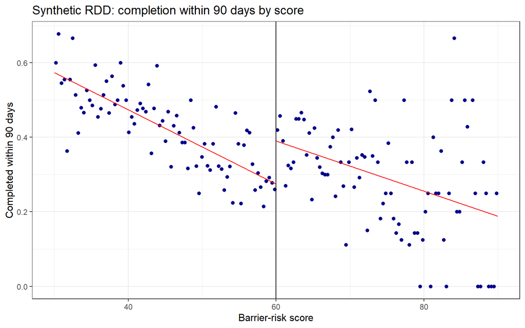

Figure 12: Synthetic RDD: 90-day completion around the eligibility cutoff.

| analysis | estimate | robust_ci_lo | robust_ci_hi | bandwidth | planted | covers_planted |
| --- | --- | --- | --- | --- | --- | --- |
| Sharp: effect of the offer (ITT) | 0.125 | 0.030 | 0.219 | 11.516 | 0.078 | TRUE |
| Fuzzy: effect of navigation (local, compliers) | 0.197 | 0.049 | 0.348 | 11.190 | 0.120 | TRUE |
| Covariate balance: age (should be ~0) | -1.034 | -4.280 | 1.422 | 8.164 | 0.000 | TRUE |
| Placebo cutoff 50 (should be ~0) | 0.082 | -0.021 | 0.219 | 3.999 | 0.000 | TRUE |
| Placebo cutoff 70 (should be ~0) | 0.079 | -0.116 | 0.274 | 4.309 | 0.000 | TRUE |
| Donut hole: exclude \|score - cutoff\| < 1 | 0.099 | -0.062 | 0.255 | 7.518 | 0.078 | TRUE |

Density (manipulation) test p-value: 0.369.

| Estimator | Mean bias | 95% CI coverage |
| --- | --- | --- |
| fuzzy (compliers) | -0.007 | 0.98 |
| sharp (ITT) | -0.006 | 0.99 |

# 8 Discrete event simulation: clinic capacity and no-shows

A booked slot is used whether or not the patient attends, so no-shows waste scarce capacity. Because navigation reduces no-shows, it can shorten waits for everyone - including patients who are not navigated - a system-level effect a cohort model cannot represent.

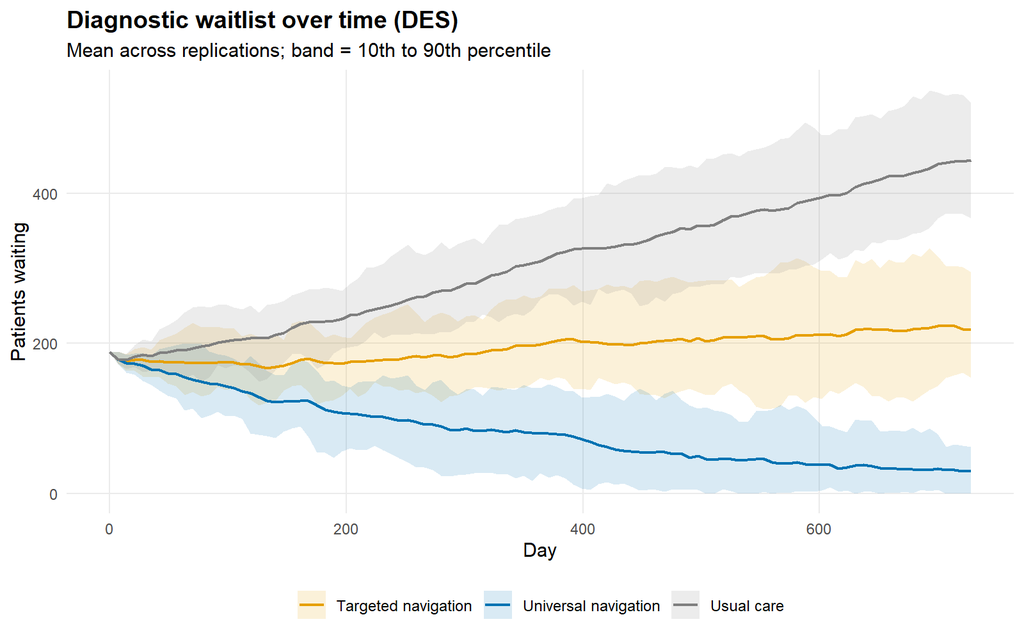

Figure 13: Diagnostic waitlist over time.

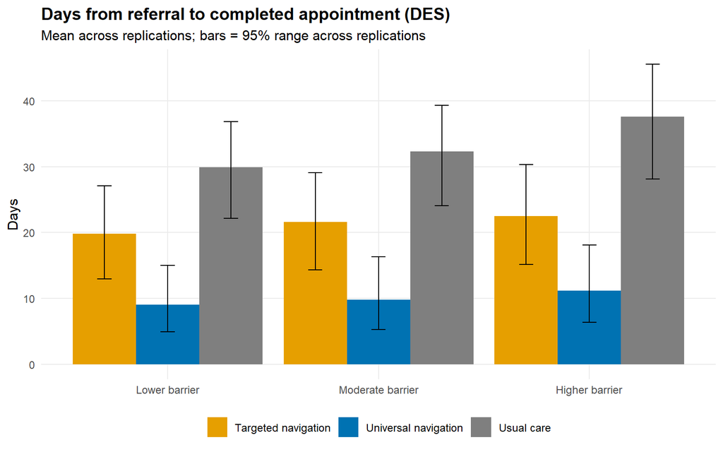

Figure 14: Days from referral to completed appointment.

| strategy | group | mean_days | p90_days | share_within_90d | mean_attempts |
| --- | --- | --- | --- | --- | --- |
| Targeted navigation | All | 21.239 | 37.212 | 0.997 | 1.149 |
| Universal navigation | All | 9.935 | 16.774 | 1.000 | 1.112 |
| Usual care | All | 33.071 | 56.256 | 0.979 | 1.184 |
| Targeted navigation | Higher barrier | 22.489 | 42.009 | 0.995 | 1.200 |
| Universal navigation | Higher barrier | 11.177 | 21.542 | 1.000 | 1.200 |
| Usual care | Higher barrier | 37.589 | 70.994 | 0.957 | 1.318 |
| Targeted navigation | Lower barrier | 19.801 | 22.516 | 0.999 | 1.089 |
| Universal navigation | Lower barrier | 9.031 | 15.184 | 1.000 | 1.051 |
| Usual care | Lower barrier | 29.902 | 38.589 | 0.993 | 1.089 |
| Targeted navigation | Moderate barrier | 21.599 | 38.820 | 0.998 | 1.164 |
| Universal navigation | Moderate barrier | 9.768 | 15.997 | 1.000 | 1.098 |
| Usual care | Moderate barrier | 32.347 | 52.738 | 0.983 | 1.164 |

# 9 Verification and validation

The automated test suite ran **40 tests** (3,794 expectations passed; 0 failed or errored).

| file | tests | expectations | failed |
| --- | --- | --- | --- |
| test-01-v1-acceptance.R | 8 | 27 | 0 |
| test-02-parameters.R | 5 | 70 | 0 |
| test-03-engine.R | 4 | 10 | 0 |
| test-04-model.R | 9 | 3648 | 0 |
| test-05-dcea.R | 5 | 17 | 0 |
| test-06-modules.R | 7 | 14 | 0 |
| test-07-regression.R | 2 | 8 | 0 |

The tests cover every defect found in the v1 blueprint, known-answer checks of the engine, null and direction tests, distribution properties, accounting identities in the DCEA, the microsimulation-cohort cross-check, planted-effect recovery in the causal modules, and regression tests against stored reference values. See `methods/verification.md`.

# 10 Limitations

- Every input is synthetic. No result is calibrated to, or validated against, real data.
- The cohort model is a single-age cohort; age, comorbidity and repeat referrals are not modelled.
- Parameters are sampled independently; correlations between inputs are not represented.
- The navigation effect is assumed to act only on pathway completion and only while support lasts.
- Opportunity-cost distribution rules and inequality aversion are value-laden scenario choices.
- The ITS and RDD data are generated from the model’s own assumptions, so their agreement with the model is a consistency check, not independent evidence.
- The DES represents one stylised clinic and is not linked to the cohort model’s outcomes.
- Barrier groups are neutral constructs; any real application needs community co-design, data governance and ethical review before groups are defined.

# 11 Reporting checklist (CHEERS 2022)

| # | Item | Where addressed |
| --- | --- | --- |
| 1-2 | Title; abstract | Title; Summary |
| 3 | Background and objectives | Summary; Decision problem |
| 4 | Health economic analysis plan | `methods/protocol.md` |
| 5-10 | Population, setting, comparators, perspective, time horizon, discount rate | Decision problem |
| 11-13 | Selection, measurement and valuation of outcomes | Model; Inputs |
| 14-15 | Resources and costs; currency and price date | Inputs; Decision problem |
| 16-17 | Rationale and description of model; analytics and assumptions | Model; `methods/model_specification.md` |
| 18 | Characterising heterogeneity | Results by group |
| 19 | Characterising distributional effects | DCEA; ECEA-lite |
| 20 | Characterising uncertainty | One-way, scenario and probabilistic analyses |
| 21 | Approach to engagement with patients and others | Not undertaken (synthetic demonstrator); required before real use |
| 22-24 | Study parameters; main results; effect of uncertainty | Inputs; Results |
| 25 | Effect of engagement | Not applicable (no engagement undertaken) |
| 26 | Findings, limitations, generalisability | Summary; Limitations |
| 27-28 | Funding; conflicts of interest | Unfunded; none declared |

# 12 Reproducibility

Run `run_all.R`, then `tests/run_tests.R`, then `quarto render`. The package versions are pinned in `renv.lock`; every output’s MD5 checksum is recorded in `outputs/run_manifest.csv`.

| section | item | value |
| --- | --- | --- |
| run | project_version | 2.0.0 |
| run | run_started | 2026-10-01 02:10:29 PDT |
| run | run_finished | 2026-10-01 02:14:13 PDT |
| run | minutes | 3.7 |
| run | r_version | R version 4.6.1 (2026-06-24 ucrt) |
| run | platform | x86_64-w64-mingw32 |
| run | master_seed | 20260921 |
| run | n_psa | 2000 |
| run | n_ecea_micro | 20000 |
| run | des_replications | 20 |
| run | its_coverage_reps | 400 |
| run | rdd_coverage_reps | 100 |
| run | wcc_method | trapezoid |
| package | ggplot2 | 4.0.3 |
| package | nlme | 3.1.169 |
| package | rdrobust | 4.0.0 |
| package | rddensity | 3.0 |
| package | simmer | 4.4.7 |
| package | testthat | 3.3.2 |
| package | knitr | 1.52 |
| package | rmarkdown | 2.32 |

48 output files were checksummed in this run.